# DATA 607, Project Two: Data Transformation - Laptop Data

Kevin Kirby

2024-09-29

## Overview

This is one of three distinct files created for project two of the Fall 2024 edition of DATA 607. This project asked me to pick three datasets posted by other students in the class and use it in a tidying and review exercise. The below is based on a laptop dataset posted by TH. I added the file to my CUNY GCP bucket and enabled public download.

```r
library(dplyr)
```

```r
library(ggplot2)
library(tidyverse)
library(readr)
library(stringr)
library(caret)
library(scales)
laptop_data_th <- read.csv("https://storage.googleapis.com/data_science_masters_files/2024_fall/data_607_data_management/project_two/laptopData.csv")
```

### Tidying the data

For the cleanup, the discussion board posted said: “the dataset has issues with missing data, duplicates, inconsistencies, and inaccuracies. Missing rows and ‘?’ entries can be addressed through data imputation or removal, while duplicates should be dropped to avoid skewed results.”

```r
tidy_laptop_data <- laptop_data_th %>%
  rename_with(tolower) %>%
  rename(
    brand = company,
    size = inches,
    screen_res = screenresolution,
    op_sys = opsys
  ) %>%
  mutate(cpu_gpu = paste(cpu, gpu, sep = "; ")) %>%
  select(
    brand,
    op_sys,
    size,
    price,
    cpu_gpu,
    memory,
    ram,
    screen_res,
    weight
  ) %>%
  drop_na() %>%
  mutate(
    weight = str_trim(weight),
    weight = str_remove_all(weight, "[^0-9.]"),
    weight = as.numeric(weight),
    weight_lb = weight * 2.20462
  )


median_weight_by_brand <- tidy_laptop_data %>%
  group_by(brand) %>%
  summarise(median_weight = median(weight, na.rm = TRUE))

tidy_laptop_data <- tidy_laptop_data %>%
  left_join(median_weight_by_brand, by = "brand") %>%
  mutate(
    weight = case_when(
      is.na(weight) ~ median_weight,
      weight < 1.0 ~ median_weight,
      TRUE ~ weight
    ),
    weight_lb = weight * 2.20462
  ) %>%
  select(-median_weight)
```

### Analysis

Here’s a box-plot of the different price ranges you see across the different brands and operating systems. This is where I started to focus in on prices and realize something wasn’t adding up.

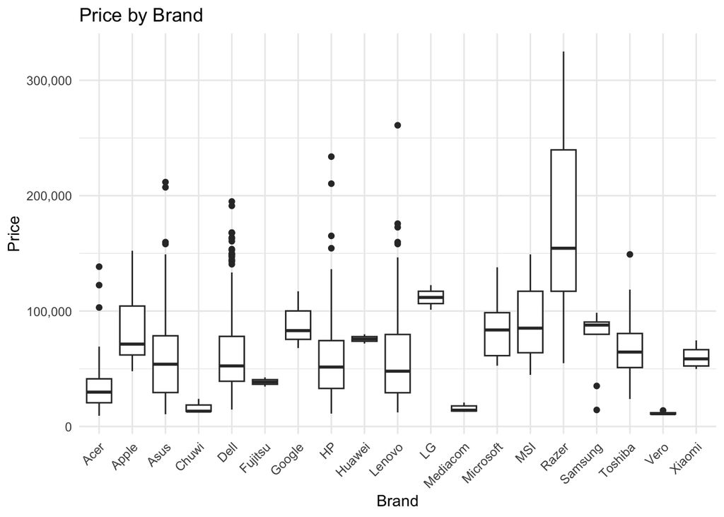

```r
ggplot(tidy_laptop_data, aes(x = brand, y = price)) +
  geom_boxplot() +
  labs(
    title = "Price by Brand",
    x = "Brand",
    y = "Price"
  ) +
  scale_y_continuous(labels = label_number(big.mark = ",")) +
  theme_minimal() +
  theme(axis.text.x = element_text(angle = 45, hjust = 1))
```

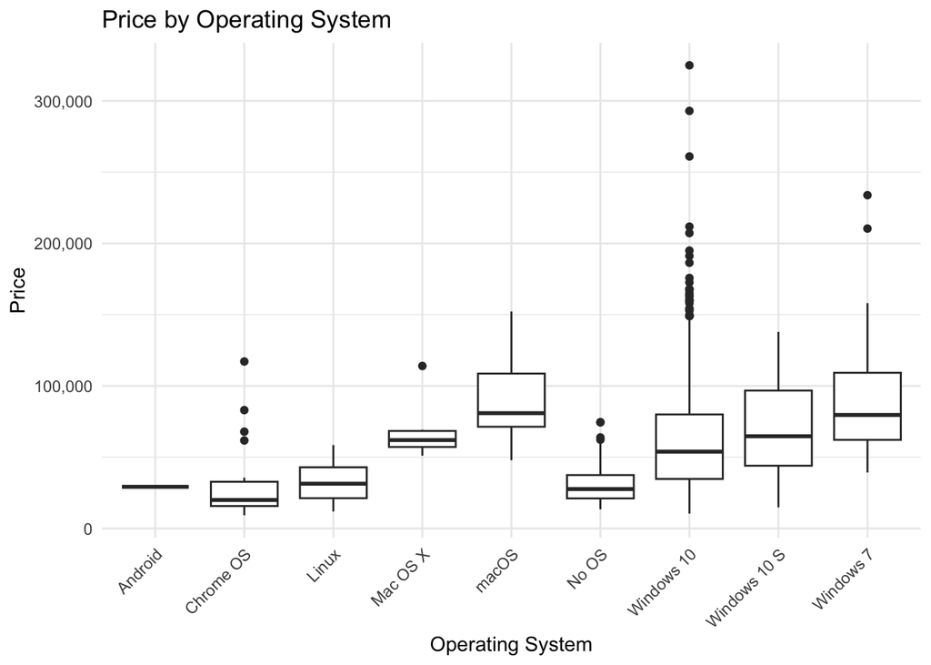

```r
ggplot(tidy_laptop_data, aes(x = op_sys, y = price)) +
  geom_boxplot() +
  labs(
    title = "Price by Operating System",
    x = "Operating System",
    y = "Price"
  ) +
  scale_y_continuous(labels = label_number(big.mark = ",")) +
  theme_minimal() +
  theme(axis.text.x = element_text(angle = 45, hjust = 1))
```

### Conclusion

I’m a bit skeptical about this dataset due to how wild these numbers are. My guess is that these prices are in some unknown foreign dollar rather than USD. I checked the original data source and couldn’t find anything additional. This data here is probably proportionally accurate but not accurate at the raw price level.